# Taller_Analisis_Factorial_I

Juan Pablo Mosquera Marin - 20221020026 Ana Laura Morcote Chacon - 20221020010 Hana Sofia Pinilla Manrique - 20221020092 Juan David Amaya Patiño - 20221020057

2026-10-17

# Actividad práctica

Con el dataset de su equipo y el cliente de su caso de negocio:

## 1.Escojan entre 4 y 10 variables numéricas que crean que comparten algo. Calculen KMO().Escojan entre 4 y 10 variables numéricas que crean que comparten algo. Calculen KMO().

```r
if (!requireNamespace("psych", quietly = TRUE)) {
  install.packages("psych", repos = "https://cloud.r-project.org")
}
```

```
##
##  C:\Users\hanap\AppData\Local\Temp\Rtmp2rwXFw\downloaded_packages
```

```r
datos_credit <- tryCatch(
  {
    readr::read_csv(here::here("DATASET", "datos_credit.csv"), show_col_types = FALSE)
  },
  error = function(e) {
    readr::read_csv(here::here("GitHub", "ESTAD.-MULTI", "DATASET", "datos_credit.csv"), show_col_types = FALSE)
  }
)



# Se reemplazan BILL_AMT5 y PAY_AMT5 por LIMIT_BAL y AGE.
# Las diez variables describen el perfil del cliente y su actividad crediticia.
variables <- c(
  "LIMIT_BAL",
  "AGE",
  paste0("BILL_AMT", 1:4),
  paste0("PAY_AMT", 1:4)
)

datos_kmo <- as.data.frame(datos_credit[, variables])
stopifnot(all(vapply(datos_kmo, is.numeric, logical(1))))

datos_kmo <- datos_kmo[complete.cases(datos_kmo), , drop = FALSE]
matriz_correlaciones <- cor(datos_kmo, method = "pearson")

resultado_kmo <- psych::KMO(matriz_correlaciones)

resultado_kmo
```

```
## Kaiser-Meyer-Olkin factor adequacy
## Call: psych::KMO(r = matriz_correlaciones)
## Overall MSA =  0.66
## MSA for each item =
## LIMIT_BAL       AGE BILL_AMT1 BILL_AMT2 BILL_AMT3 BILL_AMT4  PAY_AMT1  PAY_AMT2
##      0.89      0.66      0.77      0.69      0.68      0.77      0.41      0.28
##  PAY_AMT3  PAY_AMT4
##      0.36      0.78
```

Adecuación para el análisis factorial: KMO global y MSA por variable.

| Indicador / variable | KMO / MSA | Adecuación |
| --- | --- | --- |
| **RESULTADO GLOBAL · Adecuación del conjunto** |  |  |
| KMO global · Conjunto de las diez variables | 0,663 | Regular |
| **PERFIL DEL CLIENTE · Límite de crédito y edad** |  |  |
| LIMIT_BAL · Límite de crédito | 0,895 | Muy buena |
| AGE · Edad | 0,661 | Regular |
| **FACTURACIÓN · Montos de los estados de cuenta** |  |  |
| BILL_AMT1 · Septiembre | 0,771 | Aceptable |
| BILL_AMT2 · Agosto | 0,690 | Regular |
| BILL_AMT3 · Julio | 0,678 | Regular |
| BILL_AMT4 · Junio | 0,771 | Aceptable |
| **PAGOS · Montos efectivamente pagados** |  |  |
| PAY_AMT1 · Septiembre | 0,411 | Inadecuada |
| PAY_AMT2 · Agosto | 0,281 | Inadecuada |
| PAY_AMT3 · Julio | 0,360 | Inadecuada |
| PAY_AMT4 · Junio | 0,785 | Aceptable |

Nota: Criterio orientativo: [0,90; 1] excelente; [0,80; 0,90) muy buena; [0,70; 0,80) aceptable; [0,60; 0,70) regular; [0,50; 0,60) baja; menos de 0,50 inadecuada.

```r
# Retirar PAY_AMT1 y recalcular con las nueve variables restantes.
variables <- c(
  "LIMIT_BAL",
  "AGE",
  paste0("BILL_AMT", 1:4),
  paste0("PAY_AMT", 2:4)
)

datos_kmo <- as.data.frame(datos_credit[, variables])
stopifnot(all(vapply(datos_kmo, is.numeric, logical(1))))

datos_kmo <- datos_kmo[complete.cases(datos_kmo), , drop = FALSE]
matriz_correlaciones <- cor(datos_kmo, method = "pearson")

resultado_kmo <- psych::KMO(matriz_correlaciones)
```

KMO global y MSA por variable tras retirar PAY_AMT1.

| Indicador / variable | KMO / MSA | Adecuación |
| --- | --- | --- |
| **RESULTADO GLOBAL · Adecuación del conjunto** |  |  |
| KMO global · Conjunto de las nueve variables | 0,700 | Aceptable |
| **PERFIL DEL CLIENTE · Límite de crédito y edad** |  |  |
| LIMIT_BAL · Límite de crédito | 0,897 | Muy buena |
| AGE · Edad | 0,654 | Regular |
| **FACTURACIÓN · Montos de los estados de cuenta** |  |  |
| BILL_AMT1 · Septiembre | 0,860 | Muy buena |
| BILL_AMT2 · Agosto | 0,769 | Aceptable |
| BILL_AMT3 · Julio | 0,670 | Regular |
| BILL_AMT4 · Junio | 0,761 | Aceptable |
| **PAGOS · Montos efectivamente pagados** |  |  |
| PAY_AMT2 · Agosto | 0,253 | Inadecuada |
| PAY_AMT3 · Julio | 0,298 | Inadecuada |
| PAY_AMT4 · Junio | 0,766 | Aceptable |

```r
# Retirar PAY_AMT1 y PAY_AMT2.
variables <- c(
  "LIMIT_BAL",
  "AGE",
  paste0("BILL_AMT", 1:4),
  paste0("PAY_AMT", 3:4)
)

datos_kmo <- as.data.frame(datos_credit[, variables])
stopifnot(all(vapply(datos_kmo, is.numeric, logical(1))))

datos_kmo <- datos_kmo[complete.cases(datos_kmo), , drop = FALSE]
matriz_correlaciones <- cor(datos_kmo, method = "pearson")

resultado_kmo <- psych::KMO(matriz_correlaciones)
```

KMO global y MSA por variable tras retirar PAY_AMT1 y PAY_AMT2.

| Indicador / variable | KMO / MSA | Adecuación |
| --- | --- | --- |
| **RESULTADO GLOBAL · Adecuación del conjunto** |  |  |
| KMO global · Conjunto de las ocho variables | 0,789 | Aceptable |
| **PERFIL DEL CLIENTE · Límite de crédito y edad** |  |  |
| LIMIT_BAL · Límite de crédito | 0,883 | Muy buena |
| AGE · Edad | 0,654 | Regular |
| **FACTURACIÓN · Montos de los estados de cuenta** |  |  |
| BILL_AMT1 · Septiembre | 0,831 | Muy buena |
| BILL_AMT2 · Agosto | 0,802 | Muy buena |
| BILL_AMT3 · Julio | 0,806 | Muy buena |
| BILL_AMT4 · Junio | 0,797 | Aceptable |
| **PAGOS · Montos efectivamente pagados** |  |  |
| PAY_AMT3 · Julio | 0,382 | Inadecuada |
| PAY_AMT4 · Junio | 0,657 | Regular |

Nota: Se excluyeron PAY_AMT1 y PAY_AMT2. Todos los indicadores se recalculan con las ocho variables restantes.

```r
# Mantener excluidas PAY_AMT1 y PAY_AMT2, y retirar PAY_AMT3.
variables <- c(
  "LIMIT_BAL",
  "AGE",
  paste0("BILL_AMT", 1:4),
  "PAY_AMT4"
)

datos_kmo <- as.data.frame(datos_credit[, variables])
stopifnot(all(vapply(datos_kmo, is.numeric, logical(1))))

datos_kmo <- datos_kmo[complete.cases(datos_kmo), , drop = FALSE]
matriz_correlaciones <- cor(datos_kmo, method = "pearson")

resultado_kmo <- psych::KMO(matriz_correlaciones)
```

KMO global y MSA por variable tras retirar PAY_AMT1, PAY_AMT2 y PAY_AMT3.

| Indicador / variable | KMO / MSA | Adecuación |
| --- | --- | --- |
| **RESULTADO GLOBAL · Adecuación del conjunto** |  |  |
| KMO global · Conjunto de las siete variables | 0,836 | Muy buena |
| **PERFIL DEL CLIENTE · Límite de crédito y edad** |  |  |
| LIMIT_BAL · Límite de crédito | 0,873 | Muy buena |
| AGE · Edad | 0,643 | Regular |
| **FACTURACIÓN · Montos de los estados de cuenta** |  |  |
| BILL_AMT1 · Septiembre | 0,829 | Muy buena |
| BILL_AMT2 · Agosto | 0,795 | Aceptable |
| BILL_AMT3 · Julio | 0,847 | Muy buena |
| BILL_AMT4 · Junio | 0,878 | Muy buena |
| **PAGOS · Monto efectivamente pagado** |  |  |
| PAY_AMT4 · Junio | 0,795 | Aceptable |

Nota: Se excluyeron PAY_AMT1, PAY_AMT2 y PAY_AMT3. Todos los indicadores se recalculan con las siete variables restantes.

Ya con estas siete variables continuaremos con la extracción de factores y examinaremos sus cargas para establecer qué dimensiones representan. El KMO, por sí solo, no determina cuántos factores existen ni permite interpretarlos.

Para el banco taiwanés, con esto se puede avanzar hacia un resumen del perfil del cliente, su cupo, la facturación reciente y el pago de junio (Ya que los pagos recientes fueron los eliminados para este analisis). Podría apoyar la identificación de perfiles para intervención temprana, pero todavía no demuestra capacidad para anticipar el incumplimiento. Los pagos de septiembre, agosto y julio se excluyen únicamente de esta solución factorial. Seguen siendo varables a considerar para el general de lo solicitado por el banco, porque su baja adecuación factorial no implica que carezcan de información útil para la decisión del banco.

## 2.Corran fa(datos, nfactors = 1, fm = “ml”). Hagan la gráfica de parte común y parte propia.

```r
# Ajustar un factor por máxima verosimilitud con las siete variables.
modelo_fa <- psych::fa(
  datos_kmo,
  nfactors = 1,
  fm = "ml",
  rotate = "none"
)

print(modelo_fa)
```

```
## Factor Analysis using method =  ml
## Call: psych::fa(r = datos_kmo, nfactors = 1, rotate = "none", fm = "ml")
## Standardized loadings (pattern matrix) based upon correlation matrix
##            ML1     h2    u2 com
## LIMIT_BAL 0.29 0.0856 0.914   1
## AGE       0.06 0.0032 0.997   1
## BILL_AMT1 0.96 0.9190 0.081   1
## BILL_AMT2 0.98 0.9681 0.032   1
## BILL_AMT3 0.95 0.8981 0.102   1
## BILL_AMT4 0.92 0.8406 0.159   1
## PAY_AMT4  0.15 0.0235 0.976   1
##
##                 ML1
## SS loadings    3.74
## Proportion Var 0.53
##
## Mean item complexity =  1
## Test of the hypothesis that 1 factor is sufficient.
##
## df null model =  21  with the objective function =  6.5 with Chi Square =  194981.1
## df of  the model are 14  and the objective function was  0.35
##
## The root mean square of the residuals (RMSR) is  0.05
## The df corrected root mean square of the residuals is  0.06
##
## The harmonic n.obs is  30000 with the empirical chi square  1396.16  with prob <  1.1e-289
## The total n.obs was  30000  with Likelihood Chi Square =  10385.23  with prob <  0
##
## Tucker Lewis Index of factoring reliability =  0.92
## RMSEA index =  0.157  and the 90 % confidence intervals are  0.155 0.16
## BIC =  10240.91
## Fit based upon off diagonal values = 0.99
## Measures of factor score adequacy
##                                                    ML1
## Correlation of (regression) scores with factors   0.99
## Multiple R square of scores with factors          0.98
## Minimum correlation of possible factor scores     0.96
```

```r
# Parte común: proporción de varianza explicada por el factor.
# Parte propia: proporción de varianza no explicada por el factor.
tabla_varianzas <- data.frame(
  Variable = colnames(datos_kmo),
  Comun = unname(modelo_fa$communality),
  Propia = unname(modelo_fa$uniquenesses)
)
```

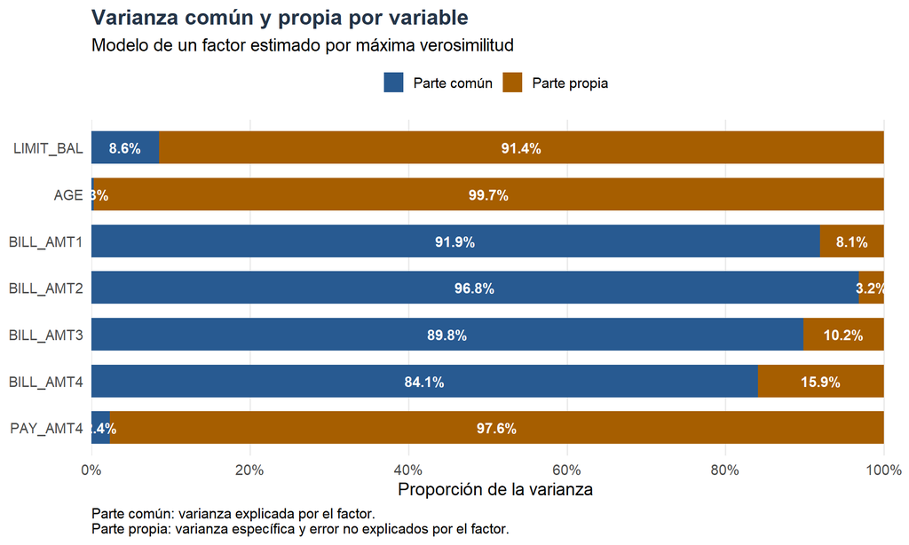

## 3.¿Qué variable es casi toda propia? ¿Qué significa eso para su cliente?

La variable AGE (edad) es casi toda parte propia: el 99,7 % de su varianza no es explicada por el factor y solo el 0,3 % es parte común. Esto indica que la edad prácticamente no comparte información con las demás variables del dataset. Mientras que los montos facturados se mueven juntos y reflejan una misma dimensión (el nivel de endeudamiento), la edad se comporta de forma independiente a ese factor.

Para el banco taiwanés, esto significa que la edad no puede resumirse ni reemplazarse mediante el factor: aporta una información distinta que no está contenida en las demás variables. Por tanto, si se quiere utilizar para identificar clientes con riesgo de incumplimiento, debe analizarse por separado, como una variable independiente, y no a través del factor.

## 4.Comprueben si una habilidad alcanza: comparen las correlaciones con el producto de las cargas.

```r
R <- cor(datos_kmo)
L <- as.numeric(modelo_fa$loadings[, 1])

producto_cargas <- outer(L, L)
error <- R - producto_cargas

# Seleccionar cada pareja una sola vez, sin incluir la diagonal.
pares <- which(upper.tri(R), arr.ind = TRUE)

comparacion <- data.frame(
  Pareja = paste(
    rownames(R)[pares[, 1]],
    colnames(R)[pares[, 2]],
    sep = " y "
  ),
  observada = R[pares],
  producto_cargas = producto_cargas[pares],
  error = error[pares]
)

knitr::kable(
  comparacion,
  digits = 3,
  row.names = FALSE
)
```

| Pareja | observada | producto_cargas | error |
| --- | --- | --- | --- |
| LIMIT_BAL y AGE | 0.145 | 0.017 | 0.128 |
| LIMIT_BAL y BILL_AMT1 | 0.285 | 0.280 | 0.005 |
| AGE y BILL_AMT1 | 0.056 | 0.055 | 0.002 |
| LIMIT_BAL y BILL_AMT2 | 0.278 | 0.288 | -0.010 |
| AGE y BILL_AMT2 | 0.054 | 0.056 | -0.002 |
| BILL_AMT1 y BILL_AMT2 | 0.951 | 0.943 | 0.008 |
| LIMIT_BAL y BILL_AMT3 | 0.283 | 0.277 | 0.006 |
| AGE y BILL_AMT3 | 0.054 | 0.054 | 0.000 |
| BILL_AMT1 y BILL_AMT3 | 0.892 | 0.908 | -0.016 |
| BILL_AMT2 y BILL_AMT3 | 0.928 | 0.932 | -0.004 |
| LIMIT_BAL y BILL_AMT4 | 0.294 | 0.268 | 0.026 |
| AGE y BILL_AMT4 | 0.051 | 0.052 | -0.001 |
| BILL_AMT1 y BILL_AMT4 | 0.860 | 0.879 | -0.019 |
| BILL_AMT2 y BILL_AMT4 | 0.892 | 0.902 | -0.010 |
| BILL_AMT3 y BILL_AMT4 | 0.924 | 0.869 | 0.055 |
| LIMIT_BAL y PAY_AMT4 | 0.203 | 0.045 | 0.158 |
| AGE y PAY_AMT4 | 0.021 | 0.009 | 0.013 |
| BILL_AMT1 y PAY_AMT4 | 0.158 | 0.147 | 0.011 |
| BILL_AMT2 y PAY_AMT4 | 0.147 | 0.151 | -0.003 |
| BILL_AMT3 y PAY_AMT4 | 0.143 | 0.145 | -0.002 |
| BILL_AMT4 y PAY_AMT4 | 0.130 | 0.141 | -0.010 |

```r
# Identificar la mayor diferencia en valor absoluto.
mayor_error <- which.max(abs(comparacion$error))

c(
  error_maximo = round(abs(comparacion$error[mayor_error]), 3)
)
```

```
## error_maximo
##        0.158
```

```r
c(
  pareja_con_mas_error = comparacion$Pareja[mayor_error]
)
```

```
##   pareja_con_mas_error
## "LIMIT_BAL y PAY_AMT4"
```

La correlación entre la facturación de septiembre y agosto es muy cercana al producto de sus cargas. Esto indica que el factor común explica bien cómo se mueven juntas estas variables. Sin embargo, la mayor diferencia aparece entre el límite de crédito y el pago de junio, cuya relación queda subestimada por el modelo. Por tanto, un solo factor representa bien el nivel de facturación, pero deja algunas relaciones sin explicar. Para el banco, sirve como una descripción parcial del cliente; conviene probar con dos factores antes de concluir si existe otra dimensión con sentido.

## 5.Prueben con dos. ¿La segunda es una habilidad con sentido, o es una sola variable?

```r
modelo_fa_2 <- psych::fa(
  datos_kmo,
  nfactors = 2,
  fm = "ml",
  rotate = "oblimin"
)

c(
  comun_con_un_factor = round(
    100 * mean(modelo_fa$communality), 1
  ),
  comun_con_dos_factores = round(
    100 * mean(modelo_fa_2$communality), 1
  ),
  correlacion_entre_factores = round(
    modelo_fa_2$Phi[1, 2], 2
  )
)
```

```
##        comun_con_un_factor     comun_con_dos_factores
##                       53.4                       55.8
## correlacion_entre_factores
##                        0.1
```

```r
round(unclass(modelo_fa_2$loadings), 2)
```

```
##            ML1   ML2
## LIMIT_BAL 0.30  0.00
## AGE       0.06  0.01
## BILL_AMT1 0.94  0.26
## BILL_AMT2 0.96  0.07
## BILL_AMT3 0.99 -0.16
## BILL_AMT4 0.95 -0.14
## PAY_AMT4  0.15  0.04
```

Al incluir dos factores, la parte común aumenta poco. El factor principal sigue concentrándose en los cuatro montos facturados, por lo que representa el nivel de facturación. El segundo presenta cargas pequeñas, con mayor peso en septiembre y valores de signo contrario en julio y junio. No corresponde estrictamente a una sola variable, pero tampoco muestra una dimensión común claramente interpretable. Aunque los factores están poco relacionados, eso no basta para justificar dos perfiles distintos. Para el banco, esta solución permite reconocer principalmente una dimensión de facturación; el segundo factor no ofrece una interpretación suficientemente clara para definir otro perfil de cliente.

# 14 Preguntas conceptuales

## 1.¿Qué diferencia hay entre la parte común y la parte propia de un módulo?

La parte comun de un módulo representa qué factor tienen en común un conjunto de variables, que no se toma de manera directa sino se deduce de como se comportan juntas. La parte propia es aquella que refiere a lo que la variable mide de manera independiente, más un error de medición.

## 2.Escritura tiene 15 de cada 100 partes comunes. ¿Significa que el módulo de escritura está mal hecho? ¿Por qué?

No necesariamente. Que solo el 15 % de su varianza sea común indica que el módulo de escritura comparte poco con la habilidad general que miden los demás módulos. El 85 % restante es parte propia: una habilidad específica que el examen mide y que el resto no captura (además del error de medición). Un módulo puede estar perfectamente bien construido y aun así medir algo distinto

## 3.Si la correlación entre dos módulos es casi igual al producto de sus cargas, ¿qué nos dice eso sobre cuántas habilidades hay?

Indica que el factor común explica aproximadamente la relación entre esos dos módulos. Si esto ocurre en todas las parejas, respalda que una sola habilidad sea suficiente para explicar sus correlaciones. Comprobarlo únicamente en una pareja no permite concluir que todo el conjunto tenga una sola habilidad.

## 4.La segunda habilidad cae casi entera sobre lectura. ¿Por qué no la llamamos «habilidad verbal»?

Porque una habilidad solo merece un nombre amplio cuando varios módulos distintos cargan en ella. Si la segunda habilidad cae casi entera sobre lectura, lo que la sostiene es un único módulo, y una habilidad que se reduce a una sola variable no es una habilidad nueva: es la variable misma. Para llamarla «habilidad verbal» tendrían que cargar también otros módulos de ese tipo, como escritura o inglés, y no lo hacen. Además, si las dos habilidades van juntas con una correlación alta, son casi la misma, por lo que tampoco justificarían dos perfiles distintos.

## 5.¿Por qué el resumen de la sesión 3 guardaba más de cada 100 que la habilidad común de hoy?

Porque buscan cosas distintas. El resumen de la sesión 3 busca el número que más separa a los estudiantes y mete todo en la componente, incluida la parte propia de cada módulo. La habilidad común, en cambio, conserva únicamente lo que los módulos comparten y separa la parte propia la específica del módulo más el error. Como el resumen se lleva de paso esa parte propia, guarda más de cada 100. Ninguno es mejor que el otro: el resumen sirve para ordenar y la habilidad común para saber cuántas habilidades hay y qué es propio de cada módulo.

## 6.¿Cuál de estas afirmaciones es correcta? (a) La habilidad común se mide directamente en la prueba. (b) La carga al cuadrado es la parte de las diferencias en un módulo que viene de la habilidad común. (c) La parte propia es siempre error de medición. (d) Si hay dos habilidades, siempre son independientes.

La correcta es la **(b)**: la carga al cuadrado es la parte de las diferencias en un módulo que viene de la habilidad común (su parte común).

- 1. es falsa: la habilidad común no se mide directamente, se deduce de cómo se mueven juntos los módulos.
- 3. es falsa: la parte propia es lo que mide ese módulo y ningún otro, más el error de medición; no es solo error.
- 4. es falsa: con una rotación como oblimin las habilidades pueden ir juntas, es decir, estar correlacionadas.